# Ford GoBike Trip Data

## by Nacer KROUDIR

- Introduction
- Preliminary Wrangling
- Questions
- General Structure
- Univariate Exploration
- Bivariate Exploration
- Multivariate Exploration
- Conclusions
- Limitations

## Introduction

This data set includes information about individual rides made by **Ford GoBike system**. This data file corresponds to February 2019 in San Francisco Bay area. The various features included in the dataset are:

- Trip Duration (seconds)
- Start Time along with date
- End Time along with date
- Start Station ID
- Start Station Name
- Start Station Latitude
- Start Station Longitude
- End Station ID
- End Station Name
- End Station Latitude
- End Station Longitude
- Bike ID
- User Type (Subscriber or Customer)
- Member birth year.
- Member gender.
- bike_share_for_all_trip.

## Preliminary Wrangling

```python
# import all packages and set plots to be embedded inline
import numpy as np
import pandas as pd
import matplotlib.pyplot as plt
import seaborn as sns
import requests
import folium
from folium.plugins import HeatMap
from sklearn.preprocessing import LabelEncoder

plt.style.use('fivethirtyeight')
base_color = sns.color_palette()[0]
%matplotlib inline
```

```python
# getting the dataframe using requests
"""
url = 'https://video.udacity-data.com/topher/2020/October/5f91cf38_201902-fordgobike-tripdata/201902-fordgobike-tripdata.csv'
response = requests.get(url)
with open('FordGoBike_tripdata.csv', mode = 'wb') as file:
    file.write(response.content)
    """
```

```
"\nurl = 'https://video.udacity-data.com/topher/2020/October/5f91cf38_201902-fordgobike-tripdata/201902-fordgobike-tripdata.csv'\nresponse = requests.get(url)\nwith open('FordGoBike_tripdata.csv', mode = 'wb') as file:\n    file.write(response.content)\n    "
```

```python
df = pd.read_csv('FordGoBike_tripdata.csv')
df.head()
```

|  | duration_sec | start_time | end_time | start_station_id | start_station_name | start_station_latitude | start_station_longitude | end_station_id | end_station_name | end_station_latitude | end_station_longitude | bike_id | user_type | member_birth_year | member_gender | bike_share_for_all_trip |
| --- | --- | --- | --- | --- | --- | --- | --- | --- | --- | --- | --- | --- | --- | --- | --- | --- |
| 0 | 52185 | 2019-02-28 17:32:10.1450 | 2019-03-01 08:01:55.9750 | 21.0 | Montgomery St BART Station (Market St at 2nd St) | 37.789625 | -122.400811 | 13.0 | Commercial St at Montgomery St | 37.794231 | -122.402923 | 4902 | Customer | 1984.0 | Male | No |
| 1 | 42521 | 2019-02-28 18:53:21.7890 | 2019-03-01 06:42:03.0560 | 23.0 | The Embarcadero at Steuart St | 37.791464 | -122.391034 | 81.0 | Berry St at 4th St | 37.775880 | -122.393170 | 2535 | Customer | NaN | NaN | No |
| 2 | 61854 | 2019-02-28 12:13:13.2180 | 2019-03-01 05:24:08.1460 | 86.0 | Market St at Dolores St | 37.769305 | -122.426826 | 3.0 | Powell St BART Station (Market St at 4th St) | 37.786375 | -122.404904 | 5905 | Customer | 1972.0 | Male | No |
| 3 | 36490 | 2019-02-28 17:54:26.0100 | 2019-03-01 04:02:36.8420 | 375.0 | Grove St at Masonic Ave | 37.774836 | -122.446546 | 70.0 | Central Ave at Fell St | 37.773311 | -122.444293 | 6638 | Subscriber | 1989.0 | Other | No |
| 4 | 1585 | 2019-02-28 23:54:18.5490 | 2019-03-01 00:20:44.0740 | 7.0 | Frank H Ogawa Plaza | 37.804562 | -122.271738 | 222.0 | 10th Ave at E 15th St | 37.792714 | -122.248780 | 4898 | Subscriber | 1974.0 | Male | Yes |

```python
df.info()
```

```
<class 'pandas.core.frame.DataFrame'>
RangeIndex: 183412 entries, 0 to 183411
Data columns (total 16 columns):
 #   Column                   Non-Null Count   Dtype
---  ------                   --------------   -----
 0   duration_sec             183412 non-null  int64
 1   start_time               183412 non-null  object
 2   end_time                 183412 non-null  object
 3   start_station_id         183215 non-null  float64
 4   start_station_name       183215 non-null  object
 5   start_station_latitude   183412 non-null  float64
 6   start_station_longitude  183412 non-null  float64
 7   end_station_id           183215 non-null  float64
 8   end_station_name         183215 non-null  object
 9   end_station_latitude     183412 non-null  float64
 10  end_station_longitude    183412 non-null  float64
 11  bike_id                  183412 non-null  int64
 12  user_type                183412 non-null  object
 13  member_birth_year        175147 non-null  float64
 14  member_gender            175147 non-null  object
 15  bike_share_for_all_trip  183412 non-null  object
dtypes: float64(7), int64(2), object(7)
memory usage: 22.4+ MB
```

- `duration_sec` is hard to understand and grasp.
- `start_time` and `end_time` are strings holding a datetime.
- `start_station_id` and `end_station_id` should be string instead of float.
- `bike_id` should be string instead of integer.
- `member_birth_year` should be integer instead of float & `age` would be a more useful feature.

```python
df.describe()
```

|  | duration_sec | start_station_id | start_station_latitude | start_station_longitude | end_station_id | end_station_latitude | end_station_longitude | bike_id | member_birth_year |
| --- | --- | --- | --- | --- | --- | --- | --- | --- | --- |
| count | 183412.000000 | 183215.000000 | 183412.000000 | 183412.000000 | 183215.000000 | 183412.000000 | 183412.000000 | 183412.000000 | 175147.000000 |
| mean | 726.078435 | 138.590427 | 37.771223 | -122.352664 | 136.249123 | 37.771427 | -122.352250 | 4472.906375 | 1984.806437 |
| std | 1794.389780 | 111.778864 | 0.099581 | 0.117097 | 111.515131 | 0.099490 | 0.116673 | 1664.383394 | 10.116689 |
| min | 61.000000 | 3.000000 | 37.317298 | -122.453704 | 3.000000 | 37.317298 | -122.453704 | 11.000000 | 1878.000000 |
| 25% | 325.000000 | 47.000000 | 37.770083 | -122.412408 | 44.000000 | 37.770407 | -122.411726 | 3777.000000 | 1980.000000 |
| 50% | 514.000000 | 104.000000 | 37.780760 | -122.398285 | 100.000000 | 37.781010 | -122.398279 | 4958.000000 | 1987.000000 |
| 75% | 796.000000 | 239.000000 | 37.797280 | -122.286533 | 235.000000 | 37.797320 | -122.288045 | 5502.000000 | 1992.000000 |
| max | 85444.000000 | 398.000000 | 37.880222 | -121.874119 | 398.000000 | 37.880222 | -121.874119 | 6645.000000 | 2001.000000 |

- There are a few `member_birth_year` that seems to be false.

```python
df.duplicated().sum()
```

```
0
```

- There are no duplicate rows in the data.

```python
df.isnull().sum()
```

```
duration_sec                  0
start_time                    0
end_time                      0
start_station_id            197
start_station_name          197
start_station_latitude        0
start_station_longitude       0
end_station_id              197
end_station_name            197
end_station_latitude          0
end_station_longitude         0
bike_id                       0
user_type                     0
member_birth_year          8265
member_gender              8265
bike_share_for_all_trip       0
dtype: int64
```

### Limitations

- There are some missing data in multiple columns.

### Problems

- `duration_sec` is hard to understand and grasp.
- `start_time` and `end_time` are strings holding a datetime.
- `start_station_id` and `end_station_id` should be string instead of float.
- `bike_id` should be string instead of integer.
- `age` would be a more useful feature to explore rather then `member_birth_year`.

### Cleaning

#### Define

create two new column `duration_minutes` and `duration_hours` to store the duration in minutes and hours Respectively.

#### Code

```python
df['duration_minutes'] = df['duration_sec'] / 60
df['duration_hours'] = df['duration_sec'] / 3600
```

#### Test

```python
df[['duration_sec', 'duration_minutes', 'duration_hours']].head()
```

|  | duration_sec | duration_minutes | duration_hours |
| --- | --- | --- | --- |
| 0 | 52185 | 869.750000 | 14.495833 |
| 1 | 42521 | 708.683333 | 11.811389 |
| 2 | 61854 | 1030.900000 | 17.181667 |
| 3 | 36490 | 608.166667 | 10.136111 |
| 4 | 1585 | 26.416667 | 0.440278 |

#### Define

convert `start_time` and `end_time` to datetime.

#### Code

```python
def convert_to_datetime(df, columns):
    """
    This function converts the type of columns in a dataframe to datetime
    parameters:
    df: The dataframe.
    columns: a list of strings that are the columns to convert.
    """
    for col in columns:
        df[col] = pd.to_datetime(df[col])
```

```python
convert_to_datetime(df, ['start_time', 'end_time'])
```

#### Test

```python
df[['start_time', 'end_time']].dtypes
```

```
start_time    datetime64[ns]
end_time      datetime64[ns]
dtype: object
```

#### Define

convert `start_station_id` and `end_station_id` to a 3 digit string.

#### Code

```python
def convert_to_string(df, columns, length):
    for col in columns:
        df[col] = df[col].astype('Int64').astype('str').str.zfill(length)
```

```python
convert_to_string(df, ['start_station_id', 'end_station_id'], 3)
```

#### Test

```python
df[['start_station_id', 'end_station_id']].head()
```

|  | start_station_id | end_station_id |
| --- | --- | --- |
| 0 | 021 | 013 |
| 1 | 023 | 081 |
| 2 | 086 | 003 |
| 3 | 375 | 070 |
| 4 | 007 | 222 |

```python
df[['start_station_id', 'end_station_id']].dtypes
```

```
start_station_id    object
end_station_id      object
dtype: object
```

#### Define

convert `bike_id` to a 4 digit string.

#### Code

```python
convert_to_string(df, ['bike_id'], 4)
```

#### Test

```python
df['bike_id'].head()
```

```
0    4902
1    2535
2    5905
3    6638
4    4898
Name: bike_id, dtype: object
```

#### Define

create a new column `age` to store the age calculated by the formula `2019 - df['member_birth_year']`

#### Code

```python
df['member_birth_year'] = df['member_birth_year'].astype('Int64')
df['age'] = 2019 - df['member_birth_year']
```

#### Test

```python
df['age'].head()
```

```
0      35
1    <NA>
2      47
3      30
4      45
Name: age, dtype: Int64
```

```python
df.head()
```

|  | duration_sec | start_time | end_time | start_station_id | start_station_name | start_station_latitude | start_station_longitude | end_station_id | end_station_name | end_station_latitude | end_station_longitude | bike_id | user_type | member_birth_year | member_gender | bike_share_for_all_trip | duration_minutes | duration_hours | age |
| --- | --- | --- | --- | --- | --- | --- | --- | --- | --- | --- | --- | --- | --- | --- | --- | --- | --- | --- | --- |
| 0 | 52185 | 2019-02-28 17:32:10.145 | 2019-03-01 08:01:55.975 | 021 | Montgomery St BART Station (Market St at 2nd St) | 37.789625 | -122.400811 | 013 | Commercial St at Montgomery St | 37.794231 | -122.402923 | 4902 | Customer | 1984 | Male | No | 869.750000 | 14.495833 | 35 |
| 1 | 42521 | 2019-02-28 18:53:21.789 | 2019-03-01 06:42:03.056 | 023 | The Embarcadero at Steuart St | 37.791464 | -122.391034 | 081 | Berry St at 4th St | 37.775880 | -122.393170 | 2535 | Customer | <NA> | NaN | No | 708.683333 | 11.811389 | <NA> |
| 2 | 61854 | 2019-02-28 12:13:13.218 | 2019-03-01 05:24:08.146 | 086 | Market St at Dolores St | 37.769305 | -122.426826 | 003 | Powell St BART Station (Market St at 4th St) | 37.786375 | -122.404904 | 5905 | Customer | 1972 | Male | No | 1030.900000 | 17.181667 | 47 |
| 3 | 36490 | 2019-02-28 17:54:26.010 | 2019-03-01 04:02:36.842 | 375 | Grove St at Masonic Ave | 37.774836 | -122.446546 | 070 | Central Ave at Fell St | 37.773311 | -122.444293 | 6638 | Subscriber | 1989 | Other | No | 608.166667 | 10.136111 | 30 |
| 4 | 1585 | 2019-02-28 23:54:18.549 | 2019-03-01 00:20:44.074 | 007 | Frank H Ogawa Plaza | 37.804562 | -122.271738 | 222 | 10th Ave at E 15th St | 37.792714 | -122.248780 | 4898 | Subscriber | 1974 | Male | Yes | 26.416667 | 0.440278 | 45 |

## Questions

### General Structure

- What is the structure of your dataset?
- What are the main features of interest in the dataset?
- What are the features in the dataset that could support our investigation?

### Univariate Exploration

- What is the distribution for the trip duration in minutes? And in hours?
- Which are the most active stations?
- What is the most ridden bike?
- What is the distribution of user type?
- What is the distribution for the bike share for all trip?
- What is the distribution for users' age? And are there any outliers?
- What is the distribution for members' gender?

### Bivariate Exploration

- What is the distribution of the stations on the map and their activity level?
- How long is the typical trip relative to the member's gender in minutes?
- How long is the typical trip for each user type in minutes?
- What is the user distribution depending on their age and user type?
- What is the average user age depending on their gender?

### Multivariate Exploration

- What is the Correlation between variables in the dataset?
- What is the relationship between age, duration and each user type?
- What is the Correlation between specific numeric variables in the dataset?

## General Structure

#### What is the structure of your dataset?

```python
df.head()
```

|  | duration_sec | start_time | end_time | start_station_id | start_station_name | start_station_latitude | start_station_longitude | end_station_id | end_station_name | end_station_latitude | end_station_longitude | bike_id | user_type | member_birth_year | member_gender | bike_share_for_all_trip | duration_minutes | duration_hours | age |
| --- | --- | --- | --- | --- | --- | --- | --- | --- | --- | --- | --- | --- | --- | --- | --- | --- | --- | --- | --- |
| 0 | 52185 | 2019-02-28 17:32:10.145 | 2019-03-01 08:01:55.975 | 021 | Montgomery St BART Station (Market St at 2nd St) | 37.789625 | -122.400811 | 013 | Commercial St at Montgomery St | 37.794231 | -122.402923 | 4902 | Customer | 1984 | Male | No | 869.750000 | 14.495833 | 35 |
| 1 | 42521 | 2019-02-28 18:53:21.789 | 2019-03-01 06:42:03.056 | 023 | The Embarcadero at Steuart St | 37.791464 | -122.391034 | 081 | Berry St at 4th St | 37.775880 | -122.393170 | 2535 | Customer | <NA> | NaN | No | 708.683333 | 11.811389 | <NA> |
| 2 | 61854 | 2019-02-28 12:13:13.218 | 2019-03-01 05:24:08.146 | 086 | Market St at Dolores St | 37.769305 | -122.426826 | 003 | Powell St BART Station (Market St at 4th St) | 37.786375 | -122.404904 | 5905 | Customer | 1972 | Male | No | 1030.900000 | 17.181667 | 47 |
| 3 | 36490 | 2019-02-28 17:54:26.010 | 2019-03-01 04:02:36.842 | 375 | Grove St at Masonic Ave | 37.774836 | -122.446546 | 070 | Central Ave at Fell St | 37.773311 | -122.444293 | 6638 | Subscriber | 1989 | Other | No | 608.166667 | 10.136111 | 30 |
| 4 | 1585 | 2019-02-28 23:54:18.549 | 2019-03-01 00:20:44.074 | 007 | Frank H Ogawa Plaza | 37.804562 | -122.271738 | 222 | 10th Ave at E 15th St | 37.792714 | -122.248780 | 4898 | Subscriber | 1974 | Male | Yes | 26.416667 | 0.440278 | 45 |

```python
df.shape
```

```
(183412, 19)
```

#### What are the main features of interest in the dataset?

The main features I focused on exploring in this notebook are:

- `duration_minutes`
- `start_station_latitude` and `start_station_longitude`
- `end_station_latitude` and `end_station_longitude`.

#### What are the features in the dataset that could support our investigation?

I used the following features to further investigate the dataset:

- `age`
- `bike_id`
- `user_type`
- `member_gender`
- `start_station_name` and `end_station_name`

## Univariate Exploration

#### What is the distribution for the trip duration in minutes? And in hours?

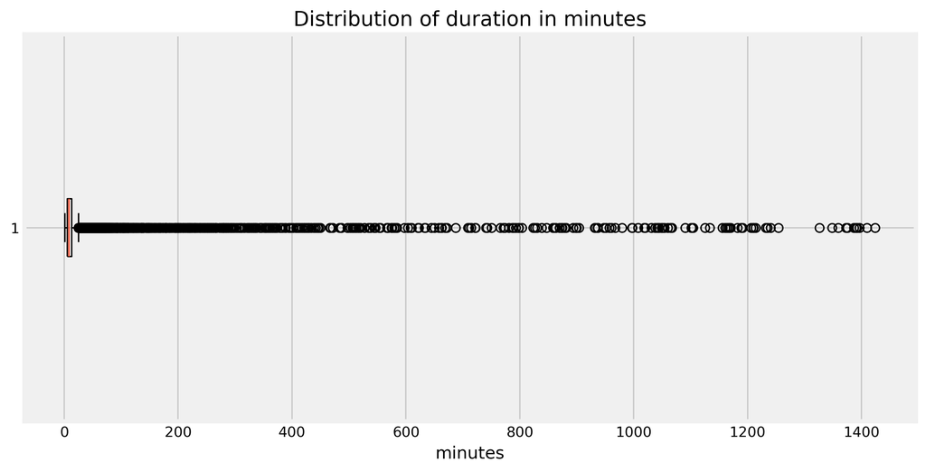

```python
plt.figure(figsize=(10,5), dpi=300)
plt.boxplot(data=df, x='duration_minutes', vert=False)
plt.title('Distribution of duration in minutes')
plt.xlabel('minutes')
plt.show()
```

There are some unusual very long durations in the dataset. We could ignore them in analysing the duration in the following. The next histogram is showing the duration upto 60 minutes only.

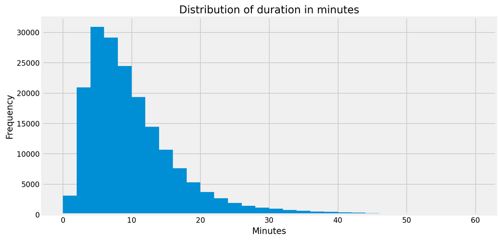

```python
bins = np.arange(0, 61, 2)
plt.figure(figsize=(10,5), dpi=200)
plt.hist(data=df, x='duration_minutes', bins=bins)
plt.title('Distribution of duration in minutes')
plt.xlabel('Minutes')
plt.ylabel('Frequency')
plt.show()
```

```python
# percentage of rides that are less than 30 minutes long
df['duration_minutes'].value_counts(normalize=True)[df['duration_minutes'].value_counts().index<=30].sum()
```

```
0.9630994700455804
```

#### Insights

- The histogram shows that over **95%** of the trips are less than **30 minutes** long.
- The longest bike rental duration took **1425** minutes equivalent to **23.75** hours.

The next histogram will show rides upto 1 hour long only.

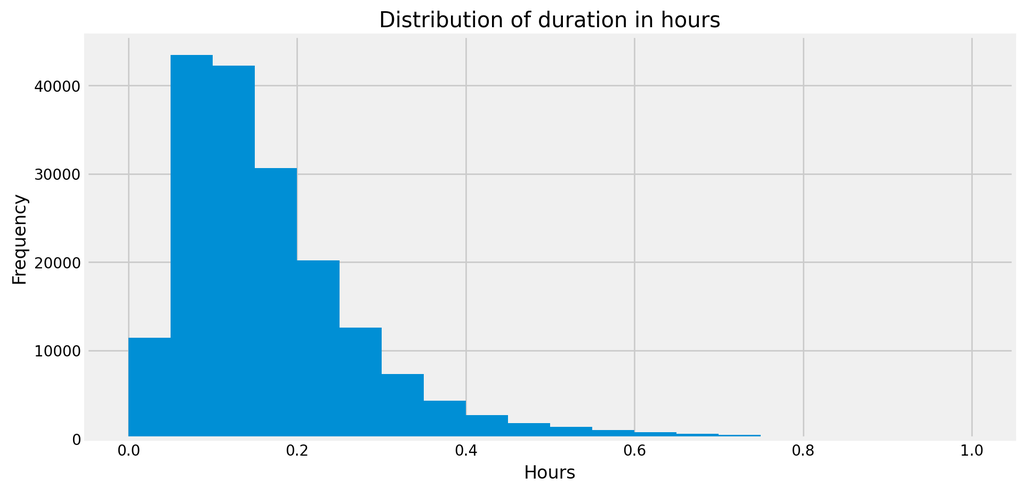

```python
bins = np.arange(0, 1.01, 0.05)
plt.figure(figsize=(10,5), dpi=200)
plt.hist(data=df, x='duration_hours', bins=bins)
plt.title('Distribution of duration in hours')
plt.xlabel('Hours')
plt.ylabel('Frequency')
plt.show()
```

#### Insights

We conclude same thing deduced from the minutes plot. Almost all the rides are less than half an hour long.

#### Which are the most active stations?

```python
# Counting the number of stations that were the start of the ride
start = df['start_station_name'].value_counts()
# Counting the number of stations that were the end of the ride
end = df['end_station_name'].value_counts()
# Joining the two series in a dataframe
active_stations = start.to_frame().join(end)
# Summing the start and end counts
active_stations['activity'] = active_stations['start_station_name'] + active_stations['end_station_name']
# sorting the values from most active to lowest active
active_stations.sort_values('activity', ascending=False, inplace=True)
```

The next plot will show the top 10 most active stations only.

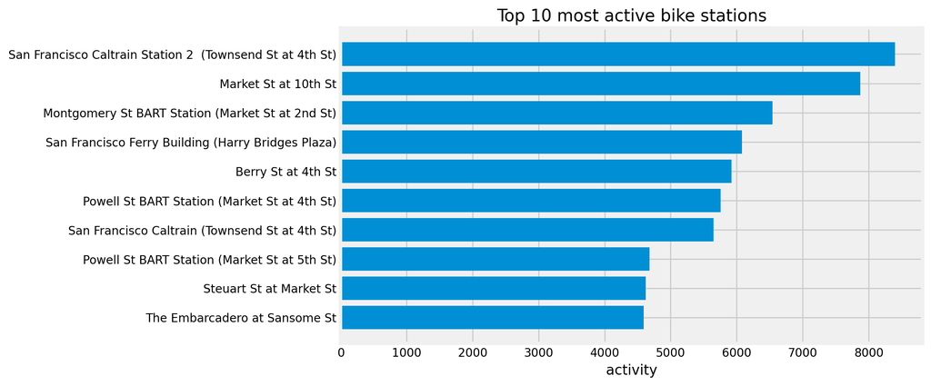

```python
plt.figure(figsize=(8,5), dpi=200)
plt.barh(active_stations.index[9::-1], active_stations.activity[9::-1])
plt.title('Top 10 most active bike stations')
plt.xlabel('activity')
plt.show()
```

**Insights**

- `San Francisco Caltrain Station 2 (Townsend St at 4th St)` is the most active bike station with **3544** starting bike rides and **4857** ending bike rides.
- The second and third most active stations are `Market St at 10th St` and `Montgomery St BART Station (Market St at 2nd St)` with **7877** and **6542** total rides respectively.

#### What is the most ridden bike?

```python
df['bike_id'].nunique()
```

```
4646
```

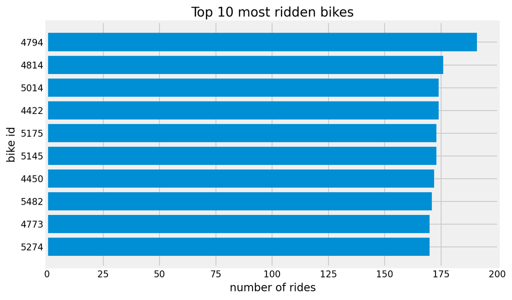

```python
top_10_bikes = df['bike_id'].value_counts()[9::-1]
plt.figure(figsize=(8,5), dpi=200)
plt.barh(top_10_bikes.keys(), top_10_bikes.values)
plt.title('Top 10 most ridden bikes')
plt.xlabel('number of rides')
plt.ylabel('bike id')
plt.show()
```

```python
# percentage of bike rides by top 1000 ridden bikes
df['bike_id'].value_counts()[:1000].sum() / df.shape[0] * 100
```

```
55.49854971321396
```

**Insights**

- There are **4646** unique bikes in San Francisco Bay area.
- The most ridden bike is bike number **4794** with 191 rides.
- The top **1000** ridden bikes represent over **55%** of trips during February 2019.

#### What is the distribution of user type?

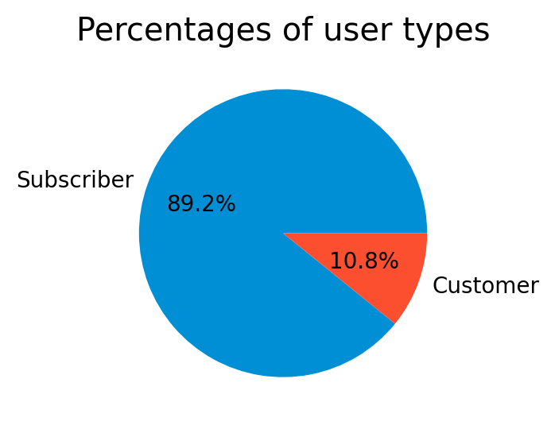

```python
user_type = df['user_type'].value_counts()
plt.figure(figsize=(3,3), dpi=200)
plt.pie(user_type.values, labels=user_type.keys(), autopct='%1.1f%%')
plt.title('Percentages of user types')
plt.show()
```

**Insights**

- **89.2%** of bike riders are subscribers.
- Only **10.8%** of bike riders are casual customers who are not subscribed.

#### What is the distribution for the bike share for all trip?

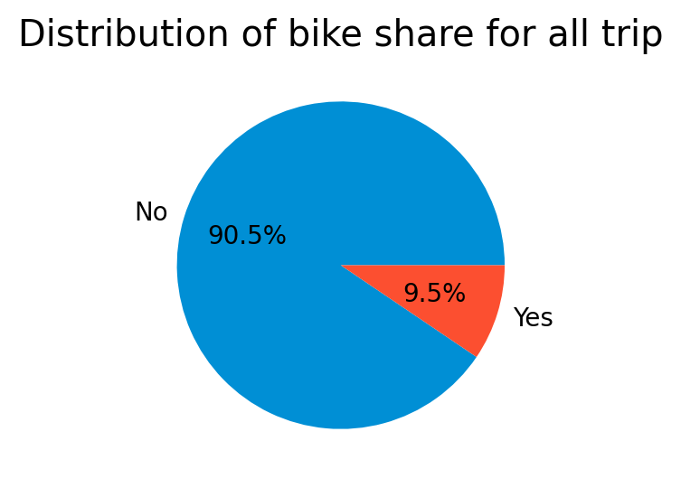

```python
bike_share = df['bike_share_for_all_trip'].value_counts()
plt.figure(figsize=(3,3), dpi=200)
plt.pie(bike_share.values, labels=bike_share.keys(), autopct='%1.1f%%')
plt.title('Distribution of bike share for all trip')
plt.show()
```

#### What is the distribution for users' age? And are there any outliers?

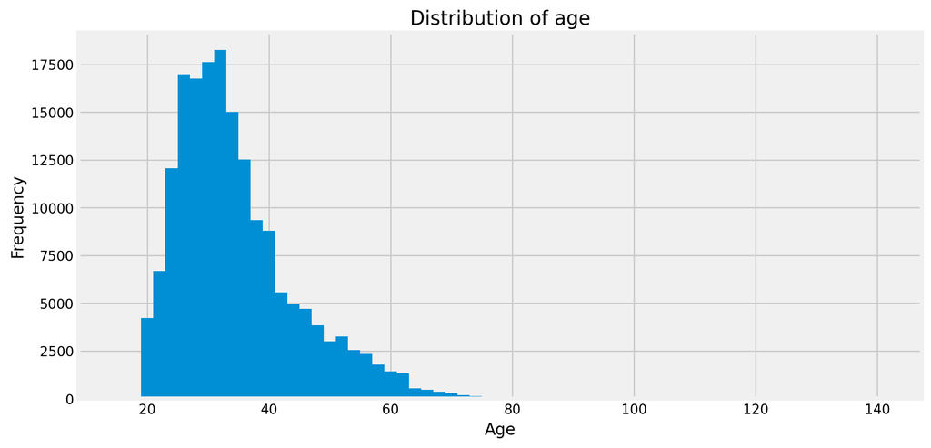

```python
bins = np.arange(15, df['age'].max()+2, 2)
plt.figure(figsize=(10,5), dpi=200)
plt.hist(data=df[df['age'].notna()], x='age', bins=bins)
plt.title('Distribution of age')
plt.xlabel('Age')
plt.ylabel('Frequency')
plt.show()
```

```python
df[df['age']<40]['age'].shape[0] / df.shape[0] * 100
```

```
73.32399188711753
```

**Insights**

- The age distribution is **positively skewed** as observed from the histogram.
- The majority of bike riders are young with a little bit over **73%** younger than **40 years old**.
- There seems to be a few **outliers** with an unrealistic old age (over 100 years old).

Let's check the outliers using boxplot

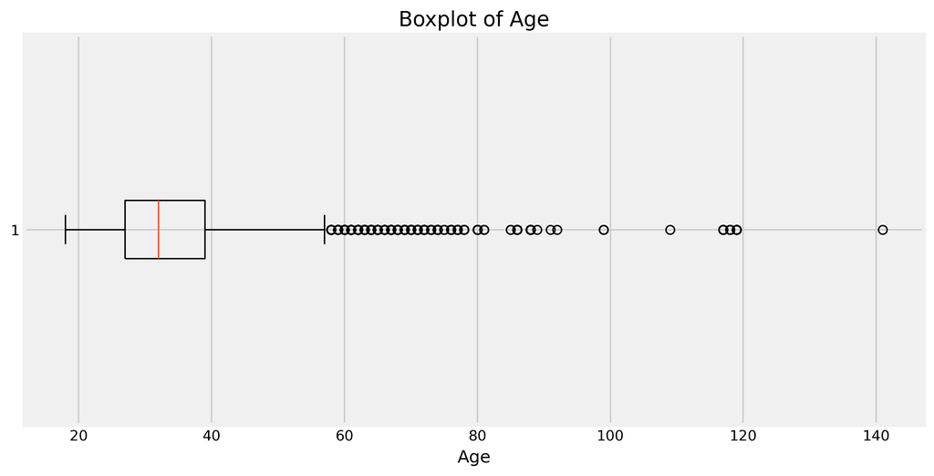

```python
plt.figure(figsize = (10,5), dpi = 300)
plt.boxplot(df[df['age'].notna()]['age'], vert=False)
plt.xlabel('Age')
plt.title("Boxplot of Age")
plt.show()
```

#### What is the distribution for members' gender?

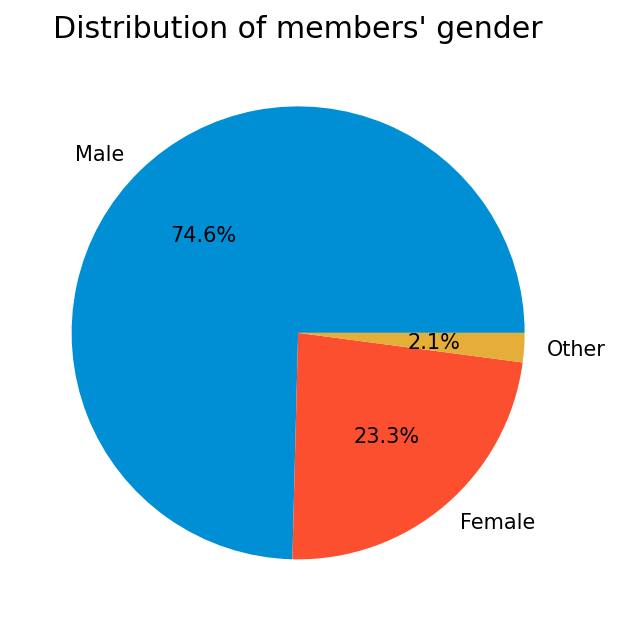

```python
gender = df['member_gender'].value_counts()
plt.figure(figsize=(5,5), dpi=150)
plt.pie(gender.values, labels=gender.keys(), autopct='%1.1f%%')
plt.title("Distribution of members' gender")
plt.show()
```

**Insights**

- **Male** are dominating the customer segmentation representing almost **three quarters** of the whole bike riders.
- The rest **quarter** is divided to **23.3% Female** and **2.1% other**.

#### What are the main features of interest in the dataset?

The main features I focused on exploring in this notebook are:

- `duration_hours`
- `start_station_latitude` and `start_station_longitude`
- `end_station_latitude` and `end_station_longitude`.

### Varibales Distribution and Comminicating Results

- For the `duration`, 95% of the trips take less than 30 minutes.

> To represent the histograms of the `duration` in minutes and in hours, I had to convert the given seconds column to the respective unit. minutes = seconds/60 | hours = seconds/3600.
> - Most bike riders are **subscribers**, not customers and **Males** represent *75%* of the users base.
> - The three most active bike stations are:
>   1. San Francisco Caltrain Station 2
>   2. Market St at 10th St
>   3. Montgomery St BART Station

> To find this I had to find the total number of appearances for the stations both as a starting point or an end destination. That number represents the amount of activity the station is receiving.

### Unusual Distributions and Outliers

- There is a negligible number of trip durations that are longer than *95%* of the trip durations, That causes the `duration` distribution to be highly **positively skewed**.
- There are some **outliers** in the `age` that can be noticed clearly in both the histogram of the distribution of the age and the boxplot. The outlier ages are over **100 years old**.

## Bivariate Exploration

#### What is the distribution of the stations on the map and their activity level?

```python
# Get start and end stations and their activity
start_markers = df[['start_station_latitude', 'start_station_longitude']].value_counts().to_frame().reset_index().values
end_markers = df[['end_station_latitude', 'end_station_longitude']].value_counts().to_frame().reset_index().values
# Add a map
trip_map = folium.Map(location=[37.6087461354128, -122.14727351791509], zoom_start=9.5)
# Add the activity as a heatmap
HeatMap(data=start_markers).add_to(folium.FeatureGroup(name='Start Stations').add_to(trip_map))
HeatMap(data=end_markers).add_to(folium.FeatureGroup(name='End Stations').add_to(trip_map))
folium.LayerControl().add_to(trip_map)
trip_map
```

Make this Notebook Trusted to load map: File -> Trust Notebook

[interactive chart not shown]

**Insights**

- There three main areas of activity on San Fransisco Bay area that are:
  1. San Fransisco
  2. Oakland
  3. San Jose

#### How long is the typical trip relative to the member's gender in minutes?

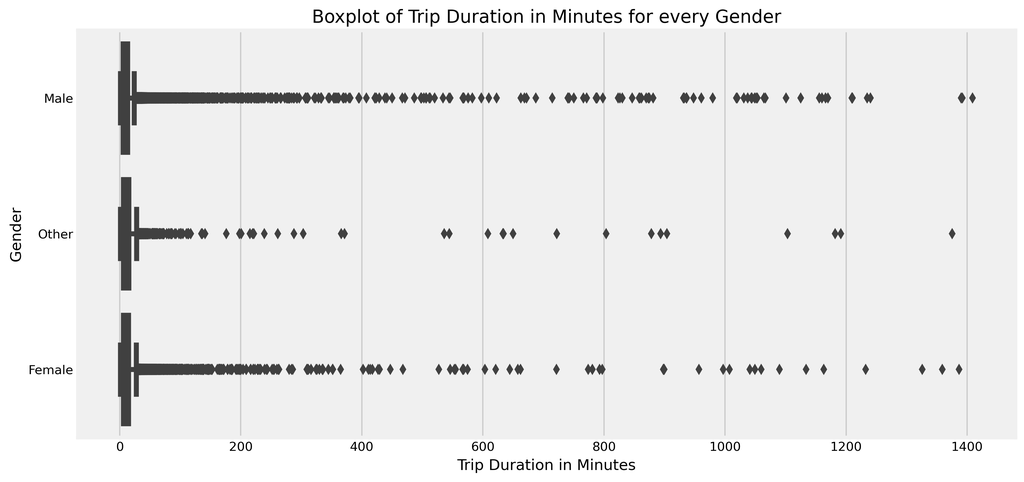

```python
plt.figure(figsize = (12,6), dpi = 300)
sns.boxplot(data=df, x='duration_minutes', y='member_gender')
plt.xlabel('Trip Duration in Minutes')
plt.ylabel('Gender')
plt.title("Boxplot of Trip Duration in Minutes for every Gender")
plt.show()
```

There isn't much to explore from this boxplot due to large number of outliers. In the next box plot I will filter out the trip duration so it's between 0 and 30 minutes only.

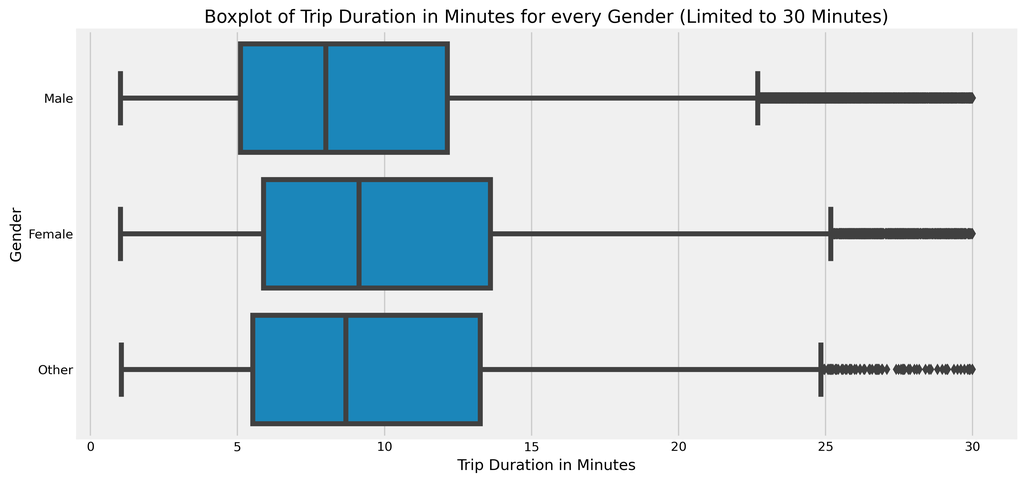

```python
plt.figure(figsize = (12,6), dpi = 300)
sns.boxplot(data=df[df['duration_minutes']<=30], x='duration_minutes', y='member_gender', color=base_color)
plt.xlabel('Trip Duration in Minutes')
plt.ylabel('Gender')
plt.title("Boxplot of Trip Duration in Minutes for every Gender (Limited to 30 Minutes)")
plt.show()
```

**Insights**

- The **IQR** for the genders is about the same.
- In general, Male trip durations tend to be **shorter** than Female trip durations.

Let's see the median duration trip for both genders

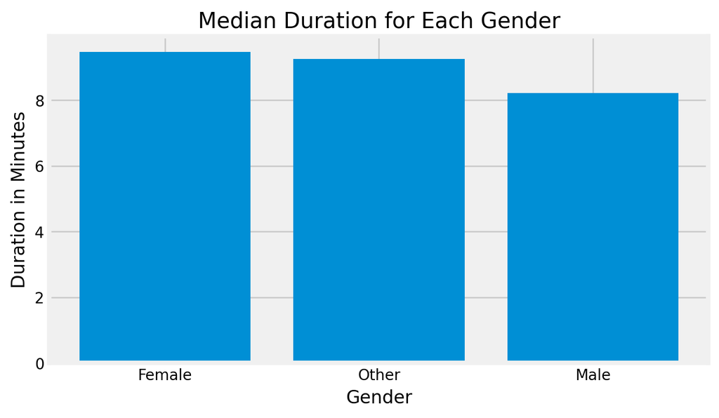

```python
avg_duration_per_gender = df.groupby('member_gender')['duration_minutes'].median().sort_values(ascending=False)
plt.figure(figsize = (7,4), dpi = 200)
plt.bar(avg_duration_per_gender.keys(), avg_duration_per_gender.values, color=base_color)
plt.xlabel('Gender')
plt.ylabel('Duration in Minutes')
plt.title('Median Duration for Each Gender')
plt.show()
```

**Insights**

- It is confirmed that trip durations for male are **shorter** than for female with a difference of about **1.25 minutes**.

#### How long is the typical trip for each user type in minutes?

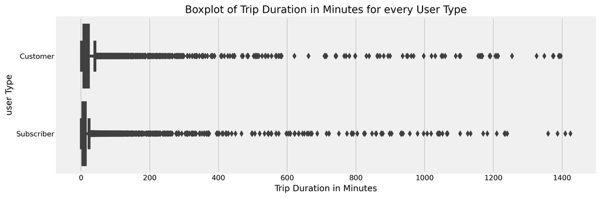

```python
plt.figure(figsize = (12,4), dpi = 300)
sns.boxplot(data=df, x='duration_minutes', y='user_type')
plt.xlabel('Trip Duration in Minutes')
plt.ylabel('user Type')
plt.title("Boxplot of Trip Duration in Minutes for every User Type")
plt.show()
```

There isn't much to explore from this boxplot due to large number of outliers. In the next box plot I will filter out the trip duration so it's between 0 and 35 minutes only.

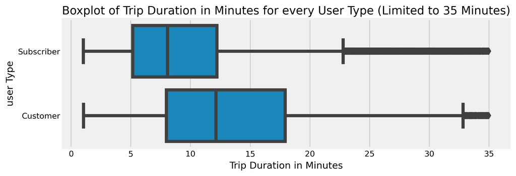

```python
plt.figure(figsize = (9,3), dpi = 300)
sns.boxplot(data=df[df['duration_minutes']<=35], x='duration_minutes', y='user_type', color=base_color)
plt.xlabel('Trip Duration in Minutes')
plt.ylabel('user Type')
plt.title("Boxplot of Trip Duration in Minutes for every User Type (Limited to 35 Minutes)")
plt.show()
```

**Insights**

- In general, *Subscribers* trip durations are **shorter** than casual *Customers* trip durations.
- This might me due to the fact that *Subscribers* are **already paying** so might as well use the bikes all the time even for short durations of time.

#### What is the user distribution depending on their age and user type?

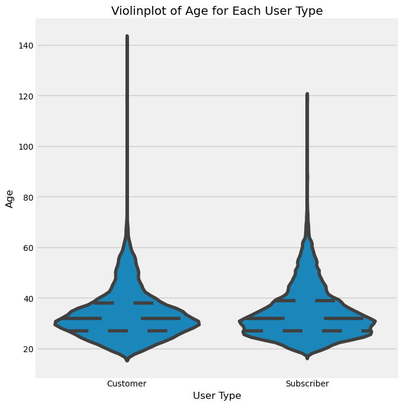

```python
plt.figure(figsize = (7,8), dpi = 100)
sns.violinplot(data=df, y=df['age'].astype('float'), x='user_type', color=base_color, inner='quartile')
plt.xlabel('User Type')
plt.ylabel('Age')
plt.title('Violinplot of Age for Each User Type')
plt.show()
```

**Insights**

- The distribution of age with respect to user types are similar.

#### What is the average user age depending on their gender?

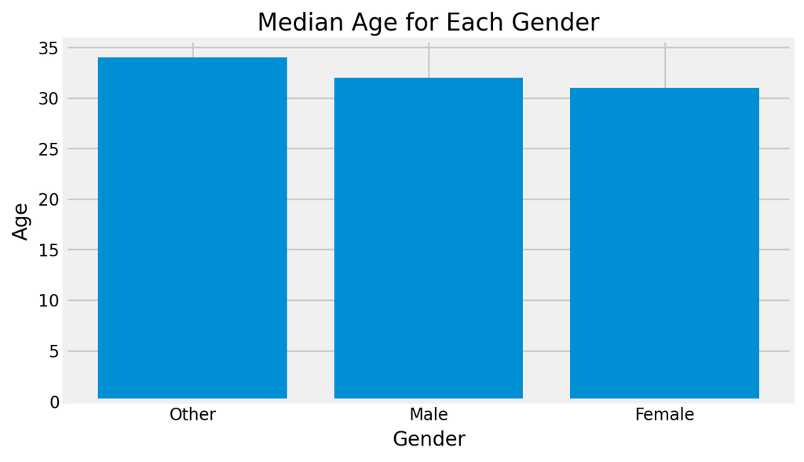

```python
avg_age_per_gender = df.groupby('member_gender')['age'].median().sort_values(ascending=False)
plt.figure(figsize = (7,4), dpi = 200)
plt.bar(avg_age_per_gender.keys(), avg_age_per_gender.values, color=base_color)
plt.xlabel('Gender')
plt.ylabel('Age')
plt.title('Median Age for Each Gender')
plt.show()
```

**Insights**

- Female have the youngest median age with **31 years old**.
- Male users are older by **1 year** only at **32 years old** median age.

### Relationships between Main Variables and Comminicating Results

- From the coordinates of the stations and their frequencies; There three main areas of activity on San Fransisco Bay area that are:
  1. San Fransisco
  2. Oakland
  3. San Jose

> To visualize the map I used `folium` library and I counted the frequency of each coordinates and used `Heatmap` to added them as layers on the map.  
> PS: The layers can be activated and deactivated on the top right corner.
> - In general, Male trip durations tend to be **shorter** than Female trip durations.

### Relationships between Other Variables

- The distributions of age with respect to user types are similar. Hence, there is **no relationship** between `age` and `user_type`.
- *Female* have the **youngest** median age of **31 years old**, followed by *Male* with **32 years old**.

> To create the corresponding visualization I grouped by `member_gender` and aggregated the median of `age`.

## Multivariate Exploration

#### What is the Correlation between variables in the dataset?

```python
# function encode features as numerical variables
def l_encoder(df, columns):
    for col in columns:
        label_encoder = LabelEncoder()
        df[col] = label_encoder.fit_transform(df.loc[:,col])
    return df
```

```python
df_enc = df.copy()
df_enc = l_encoder(df_enc, ['member_gender', 'user_type', 'bike_share_for_all_trip', 'end_station_id', 'start_station_id', 'bike_id'])
```

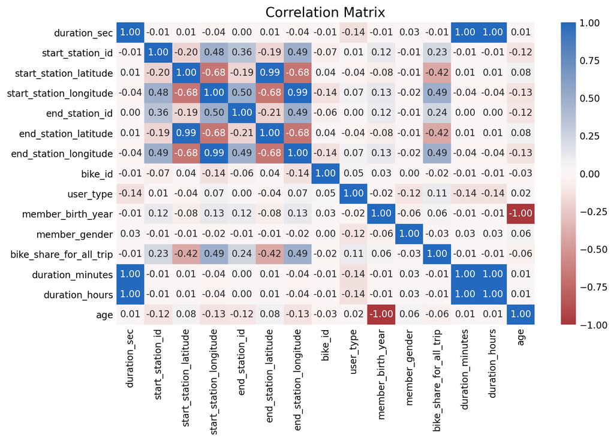

```python
plt.figure(figsize=(9,6), dpi=200)
sns.heatmap(df_enc.corr(), annot=True, fmt='.2f', cmap='vlag_r', center=0);
plt.title("Correlation Matrix")
plt.xticks(rotation=90)
plt.show()
```

**Insights**

- There is a **strong positive** correlation between the `latitude` of both start and end stations and `longitude` of both start and end stations.
- The `duration` in all its units is *100%* correlated as expected.
- The **negative** 100% correlation between `age` and `member_birth_year` is logical.

#### What is the relationship between age, duration and each user type?

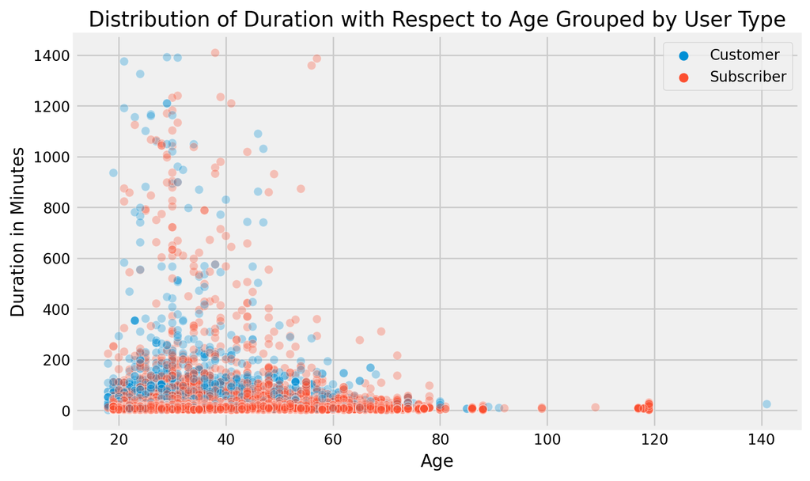

```python
plt.figure(figsize = (8,5), dpi = 200)
sns.scatterplot(data=df, x='age', y='duration_minutes', hue='user_type', alpha=0.3)
plt.xlabel('Age')
plt.ylabel('Duration in Minutes')
plt.title('Distribution of Duration with Respect to Age Grouped by User Type')
plt.legend()
plt.show()
```

**Insights**

- `age` is highly concentrated between *20* and *40* years old.
- `duration` is distributed mostly **less than** *30* minutes.
- The `user_type` is distributed through the whole dataset and thus it isn't distinguishable through `age` and `duration`.

#### What is the Correlation between specific numeric variables in the dataset?

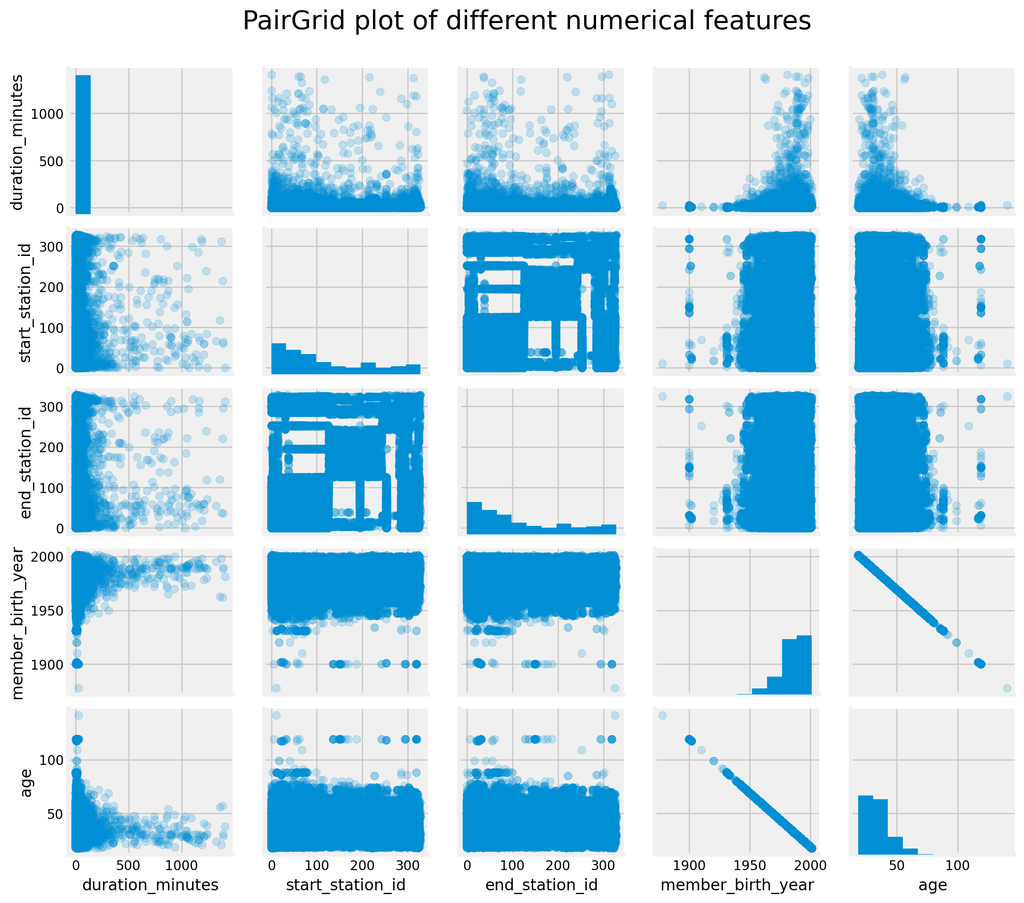

```python
df_enc.dropna(inplace=True)
g = sns.PairGrid(data=df_enc, vars=['duration_minutes', 'start_station_id', 'end_station_id', 'member_birth_year', 'age'])
g.map_diag(plt.hist)
g.map_offdiag(plt.scatter, alpha=0.2)
g.fig.set_size_inches(11, 9)
g.fig.dpi = 200
g.fig.suptitle("PairGrid plot of different numerical features", fontsize=20, y=1.05)
plt.show()
```

## Conclusions

- **95%** of the trips take less than **30 minutes**.
- Most bike riders are **Subscribers**, not customers and **Males** represent *75%* of the users base.
- From the coordinates of the stations and their frequencies; There three main areas of activity on San Fransisco Bay area that are:
  1. San Fransisco
  2. Oakland
  3. San Jose
- The three most active bike stations are:
  1. San Francisco Caltrain Station 2
  2. Market St at 10th St
  3. Montgomery St BART Station
- In general, Male trip durations tend to be **shorter** than Female trip durations.
- **Subscribers** trip durations are **shorter** than **Customers** trip durations.
- The distributions of age with respect to user types are similar. Hence, there is **no relationship** between `age` and `user_type`.
- *Female* have the **youngest** median age of **31 years old**, followed by *Male* with **32 years old**.

## Limitations

- There are a few missing data.
- There are a few outliers when it comes to age.